# Experience with access regime policies influences compliance and enforcement behaviors of common-pool resource users

Ignacia Rivera

# Data analysis and figures

## **1. Data description**

1. **union:** unique id for each union (not disclosed to ensure anonymity)
2. **performance:** type of association
- High performance = 1
- Low performance = 2
3. **framing:** framing under which the game was played
- Loco = 1
- Hake = 2
4. **id:** unique number for subject identification built combining codes for id, union and frame
5. **group_id:** unique number for group identification built combining codes for union, session and frame (note that groups were reassembled in each round for union 3 due to an implementation error)
6. **round:** round of the game
- From 1 to 20
7. **overextraction:** number of units overharvested by a subject in a given round
- From 0 to 50
8. **observer:** the role assigned to that subject in that round
- Observer = 1
- Inactive = -1
- Inspected = 0
- Round with no observation = NA
9. **overext_observed:** overextraction performed by the subject being inspected by the subject
- From 0 to 50
- Round with no observation = NA
10. **report:** whether the subject reported a parnter’s violation when having the chance
- Yes = 1
- No = 0
- Round with no obsrevation = NA
11. **punished:** whether the subject got punished after being observed violating the quota
- Yes = 1
- No = 0
- Round with no obsrevation = NA
12. **round_profit:** profit made by the subject in a given round
- From 0 to 1,500

| union | performance | framing | id | group_id | round | overextraction | observer | overext_observed | report | punished | round_profit | group id fixed | compliance | stage | stage nm | frame nm | performance nm |
| --- | --- | --- | --- | --- | --- | --- | --- | --- | --- | --- | --- | --- | --- | --- | --- | --- | --- |
| 1 | 1 | 1 | 32111 | 121 | 1 | 25 | NA | NA | NA | NA | 930 | 121 | 50 | 1 | Nonenforced | Loco | High performance |
| 1 | 1 | 1 | 64211 | 111 | 1 | 15 | NA | NA | NA | NA | 1050 | 111 | 70 | 1 | Nonenforced | Loco | High performance |
| 1 | 1 | 1 | 96311 | 121 | 1 | 50 | NA | NA | NA | NA | 1300 | 121 | 0 | 1 | Nonenforced | Loco | High performance |
| 1 | 1 | 1 | 128411 | 111 | 1 | 0 | NA | NA | NA | NA | 820 | 111 | 100 | 1 | Nonenforced | Loco | High performance |
| 1 | 1 | 1 | 160511 | 111 | 1 | 0 | NA | NA | NA | NA | 820 | 111 | 100 | 1 | Nonenforced | Loco | High performance |
| 1 | 1 | 1 | 192611 | 121 | 1 | 0 | NA | NA | NA | NA | 550 | 121 | 100 | 1 | Nonenforced | Loco | High performance |

## **2. Differences in compliance**

### 2.a. Non-parametric tests for differences in individual mean compliance

Wilcoxon rank-sum: differences in compliance levels

| performance | frame | stage | p.value | stat | corrected.p.value | sign.corrected |
| --- | --- | --- | --- | --- | --- | --- |
| High performance | vs | All | 0.000 | 965.0 | 0.000 | * |
| Low performance | vs | All | 0.204 | 1557.5 | 1.628 |  |
| vs | Hake | All | 0.638 | 1710.0 | 5.105 |  |
| vs | Loco | All | 0.003 | 2362.5 | 0.024 | * |
| High performance | Hake | vs | 0.020 | 92.0 | 0.163 |  |
| Low performance | Hake | vs | 0.577 | 130.0 | 4.616 |  |
| High performance | Loco | vs | 0.056 | 47.0 | 0.447 |  |
| Low performance | Loco | vs | 0.019 | 91.0 | 0.153 |  |

Significance level is ajusted using a Bonferroni correction for 8 hypotheses  
Tests comparing differences between stages are paired

### 2.b. Plot of mean individual compliance per treatment and association type

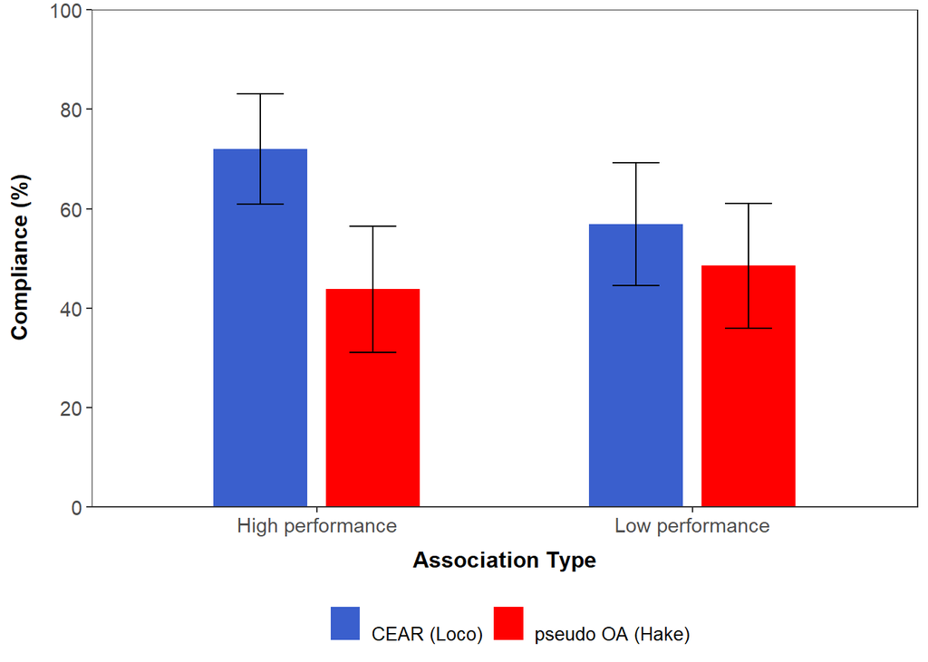

### 2.c. Comparing number of subjects that choose to comply in every round between treatments within association types

Fisher's exact test for count data: differences in number of compliers between frames

| Performance | odds ratio | p.value | corrected.p.value |
| --- | --- | --- | --- |
| High performance | 6.786 | 0.021 | 0.042 |
| Low performance | 2.047 | 1 | 2 |

Significance level is ajusted using a Bonferroni correction for 2 hypotheses

### 2.d. Regressing group compliance over treatment, association type and stage

|  | *Dependent variable:* |  |  |  |  |  |
| --- | --- | --- | --- | --- | --- | --- |
|  | Group percent of compliance |  |  |  |  |  |
|  | (1) | (2) | (3) | (4) | (5) | (6) |
| CEAR | 18.28*** | 18.28*** | 18.28*** | 6.73 | 6.73 | 11.34 |
|  | (2.62) | (2.56) | (2.55) | (4.86) | (4.84) | (8.82) |
| Peer-enforced stage |  | 6.77*** | 3.67 | 4.37 | 1.27 | 7.62 |
|  |  | (2.56) | (4.52) | (4.46) | (5.86) | (8.21) |
| HP |  | 5.17** | 5.17** | -5.50 | -5.50 | -7.94 |
|  |  | (2.56) | (2.55) | (4.24) | (4.25) | (7.51) |
| Non-enforced rounds |  |  | -1.10* |  | -1.10* |  |
|  |  |  | (0.65) |  | (0.64) |  |
| Peer-enforced rounds |  |  | -0.41 |  | -0.41 |  |
|  |  |  | (0.60) |  | (0.59) |  |
| CEAR x Peer-enf. stage |  |  |  | 3.27 | 3.27 | -8.04 |
|  |  |  |  | (5.00) | (4.99) | (8.92) |
| CEAR x HP |  |  |  | 19.81*** | 19.81*** | 23.60*** |
|  |  |  |  | (5.00) | (4.99) | (8.92) |
| Peer-enf. stage x HP |  |  |  | 1.53 | 1.53 | 0.14 |
|  |  |  |  | (5.00) | (4.99) | (8.92) |
| CEAR × HP × Non-enf. rounds |  |  |  |  |  | -2.02* |
|  |  |  |  |  |  | (1.13) |
| CEAR × HP × Peer-enf. rounds |  |  |  |  |  | 0.18 |
|  |  |  |  |  |  | (0.76) |
| Pseudo-OA × HP × Non-enf. rounds |  |  |  |  |  | -0.06 |
|  |  |  |  |  |  | (1.07) |
| Pseudo-OA × HP × Peer-enf. rounds |  |  |  |  |  | -0.57 |
|  |  |  |  |  |  | (1.34) |
| CEAR × LP × Non-enf. rounds |  |  |  |  |  | -1.62 |
|  |  |  |  |  |  | (1.45) |
| CEAR × LP × Peer-enf. rounds |  |  |  |  |  | 0.07 |
|  |  |  |  |  |  | (1.17) |
| Pseudo-OA × LP × Non-enf. rounds |  |  |  |  |  | -0.70 |
|  |  |  |  |  |  | (1.20) |
| Pseudo-OA × LP × Peer-enf. rounds |  |  |  |  |  | -1.32 |
|  |  |  |  |  |  | (1.24) |
| Constant | 46.18*** | 40.21*** | 45.16*** | 46.36*** | 51.31*** | 49.28*** |
|  | (1.79) | (2.56) | (3.84) | (3.51) | (4.54) | (6.29) |
| AIC | 4125.52535454189 | 4117.35251141161 | 4117.46679131811 | 4105.78390584799 | 4105.73916532232 | 4114.8963801493 |
| Observations | 440 | 440 | 440 | 440 | 440 | 440 |
| R<sup>2</sup> | 0.11 | 0.14 | 0.14 | 0.17 | 0.18 | 0.18 |
| Adjusted R<sup>2</sup> | 0.11 | 0.13 | 0.13 | 0.16 | 0.16 | 0.16 |
| Residual Std. Error | 19.10 (df = 438) | 18.88 (df = 436) | 18.84 (df = 434) | 18.57 (df = 433) | 18.53 (df = 431) | 18.60 (df = 425) |
| *Note:* | p<0.1; p<0.05; p<0.01 |  |  |  |  |  |
|  | Weights are assigned based on the number of individuals in each group |  |  |  |  |  |
|  | Robust standard errors |  |  |  |  |  |

## **3. Differences in peer-enforcement**

### 3.a. Nonparametric test for differences in individual report probability

Wilcoxon rank-sum test: differences in individual probability of reporting

| performance.nm | frame.nm | statistic | p.value | corrected.p.value |
| --- | --- | --- | --- | --- |
| High performance | vs | 215.5 | 0.027 | 0.106 |
| Low performance | vs | 353.5 | 0.217 | 0.868 |
| vs | Hake | 560.5 | 0.015 | 0.062 |
| vs | Loco | 476.0 | 0.004 | 0.016 |

Significance level is ajusted using a Bonferroni correction for 4 hypotheses

### 3.b. Plot of mean individual probability of reporting per treatment and association type

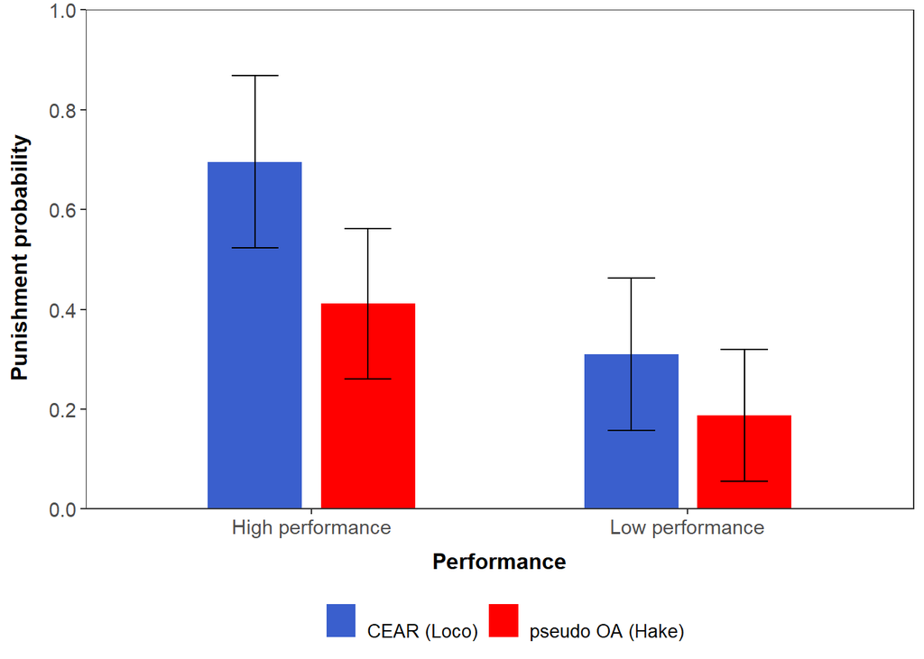

### 3.d. Regressing group probability of reporting over treatment, association type and stage

|  | *Dependent variable:* |  |  |  |  |  |  |  |
| --- | --- | --- | --- | --- | --- | --- | --- | --- |
|  | group.prob.report |  |  |  |  |  |  |  |
|  | (1) | (2) | (3) | (4) | (5) | (6) | (7) | (8) |
| cear | 0.21*** | 0.21*** | 0.22*** | 0.24*** | 0.10 | 0.12* |  |  |
|  | (0.06) | (0.06) | (0.06) | (0.06) | (0.07) | (0.07) |  |  |
| round |  | -0.01 |  | -0.01 |  | -0.01 |  | -0.01 |
|  |  | (0.01) |  | (0.01) |  | (0.01) |  | (0.01) |
| mean.obs.overharvest |  | 0.001 |  | 0.002 |  | 0.002 |  | 0.002 |
|  |  | (0.002) |  | (0.002) |  | (0.002) |  | (0.002) |
| hp |  |  | 0.24*** | 0.24*** | 0.13* | 0.13* |  |  |
|  |  |  | (0.06) | (0.05) | (0.07) | (0.07) |  |  |
| cear.hp |  |  |  |  | 0.24** | 0.26** |  |  |
|  |  |  |  |  | (0.11) | (0.11) |  |  |
| oa.hp |  |  |  |  |  |  | -0.35*** | -0.37*** |
|  |  |  |  |  |  |  | (0.08) | (0.09) |
| cear.lp |  |  |  |  |  |  | -0.37*** | -0.38*** |
|  |  |  |  |  |  |  | (0.08) | (0.08) |
| oa.lp |  |  |  |  |  |  | -0.48*** | -0.50*** |
|  |  |  |  |  |  |  | (0.08) | (0.08) |
| Constant | 0.28*** | 0.43** | 0.16*** | 0.27 | 0.22*** | 0.32* | 0.69*** | 0.82*** |
|  | (0.04) | (0.17) | (0.05) | (0.17) | (0.05) | (0.17) | (0.07) | (0.16) |
| Observations | 187 | 187 | 187 | 187 | 187 | 187 | 187 | 187 |
| R<sup>2</sup> | 0.07 | 0.07 | 0.15 | 0.16 | 0.18 | 0.19 | 0.18 | 0.19 |
| Adjusted R<sup>2</sup> | 0.06 | 0.06 | 0.15 | 0.14 | 0.16 | 0.16 | 0.16 | 0.16 |
| Residual Std. Error | 0.29 (df = 185) | 0.29 (df = 183) | 0.28 (df = 184) | 0.28 (df = 182) | 0.28 (df = 183) | 0.28 (df = 181) | 0.28 (df = 183) | 0.28 (df = 181) |
| F Statistic | 13.03*** (df = 1; 185) | 4.74*** (df = 3; 183) | 16.83*** (df = 2; 184) | 8.82*** (df = 4; 182) | 13.16*** (df = 3; 183) | 8.34*** (df = 5; 181) | 13.16*** (df = 3; 183) | 8.34*** (df = 5; 181) |
| *Note:* | p<0.1; p<0.05; p<0.01 |  |  |  |  |  |  |  |
|  | Weights are assigned based on the number of individuals in each group |  |  |  |  |  |  |  |
|  | Robust standard errors |  |  |  |  |  |  |  |

## **4. The effect of peer-enforcement on compliance**

### 4.a. Nonparametric tests for evolution of compliance

Wilcoxon rank-sum paired test: differences in compliance between the first and last round in each stage

| frame | stage | statistic | p.value | corrected.p.value | sign.corrected |
| --- | --- | --- | --- | --- | --- |
| High performance |  |  |  |  |  |
| Hake | nonenforced | 78.5 | 0.519 | 4.149 |  |
| Loco | nonenforced | 147.0 | 0.001 | 0.007 | ** |
| Hake | peer-enforced | 80.5 | 0.254 | 2.036 |  |
| Loco | peer-enforced | 7.0 | 0.272 | 2.175 |  |
| Low performance |  |  |  |  |  |
| Hake | nonenforced | 122.5 | 0.111 | 0.890 |  |
| Loco | nonenforced | 142.0 | 0.061 | 0.488 |  |
| Hake | peer-enforced | 42.5 | 0.421 | 3.368 |  |
| Loco | peer-enforced | 44.5 | 0.695 | 5.556 |  |

Significance level is ajusted using a Bonferroni correction for 8 hypotheses

### 4.b. Plot of evolution of individual compliance

[figure not shown]

### 4.c. Plot of evolution of probability of reporting in each round

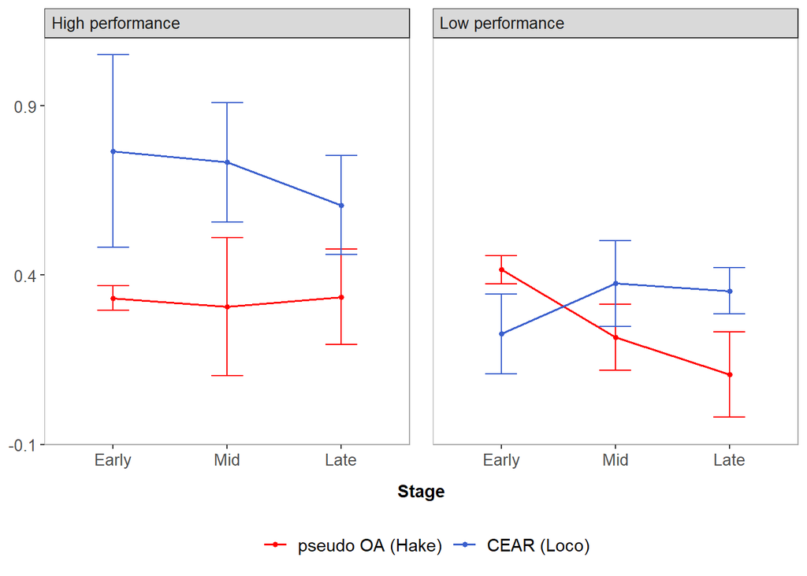

## **5. Individual determinants of compliance and peer-neforcement**

### 5.a. Regressing individual compliance in peer-enforced stage on game variables (OLS)

|  | *Dependent variable:* |  |  |  |
| --- | --- | --- | --- | --- |
|  | compliance |  |  |  |
|  | (1) | (2) | (3) | (4) |
| avg.comp.non.enf | 0.83*** | 0.96*** | 0.94*** | 0.92*** |
|  | (0.04) | (0.04) | (0.04) | (0.04) |
| avg.oth.comp.prev | -0.32*** | 0.29*** | -0.16*** | 0.07 |
|  | (0.06) | (0.05) | (0.06) | (0.07) |
| punished.prev.round | -9.11 | -4.59 | 5.93 | 17.49* |
|  | (5.88) | (4.61) | (6.96) | (9.53) |
| punished.prev.prev.round | 4.59 | 3.91 | -2.87 | 7.92 |
|  | (4.46) | (5.07) | (7.16) | (9.13) |
| report.prev.round | 4.04 | 1.07 | 13.32*** | 2.90 |
|  | (4.63) | (3.85) | (5.12) | (6.29) |
| peer.enf.rounds | 0.92* | -0.82** | -0.40 | -0.88 |
|  | (0.48) | (0.40) | (0.50) | (0.62) |
| Constant | 39.36*** | -1.51 | 21.71*** | 5.82 |
|  | (5.58) | (3.23) | (5.17) | (4.11) |
| Observations | 300 | 300 | 300 | 300 |
| R<sup>2</sup> | 0.58 | 0.75 | 0.63 | 0.52 |
| Adjusted R<sup>2</sup> | 0.57 | 0.75 | 0.62 | 0.51 |
| Residual Std. Error (df = 293) | 22.88 | 21.06 | 24.37 | 30.07 |
| F Statistic (df = 6; 293) | 66.89*** | 148.81*** | 83.01*** | 53.44*** |
| *Note:* | p<0.1; p<0.05; p<0.01 |  |  |  |
|  | Robust standard errors |  |  |  |

### 5.b. Regressing individual compliance in peer-enforced stage on game variables (OLS with individual random effects)

|  | *Dependent variable:* |  |  |  |
| --- | --- | --- | --- | --- |
|  | compliance |  |  |  |
|  | (1) | (2) | (3) | (4) |
| avg.comp.non.enf | 0.79*** | 1.00*** | 0.88*** | 0.86*** |
|  | (0.11) | (0.07) | (0.09) | (0.14) |
| avg.oth.comp.prev | 0.01 | 0.20*** | 0.02 | 0.13 |
|  | (0.09) | (0.07) | (0.09) | (0.09) |
| punished.prev.round | -2.22 | -1.29 | 11.53** | 7.83 |
|  | (3.26) | (3.84) | (4.70) | (5.17) |
| punished.prev.prev.round | 11.93*** | 7.71* | 3.03 | -0.17 |
|  | (3.43) | (4.08) | (5.15) | (4.95) |
| report.prev.round | -0.12 | 1.07 | 6.61 | -2.76 |
|  | (3.22) | (3.90) | (4.78) | (5.37) |
| peer.enf.rounds | 0.41 | -0.90** | -0.58 | -0.94** |
|  | (0.35) | (0.37) | (0.43) | (0.39) |
| Constant | 18.89** | 0.99 | 14.50** | 7.55 |
|  | (9.50) | (4.64) | (6.45) | (8.45) |
| Observations | 300 | 300 | 300 | 300 |
| Log Likelihood | -1,293.26 | -1,313.78 | -1,347.29 | -1,343.79 |
| Akaike Inf. Crit. | 2,604.51 | 2,645.56 | 2,712.58 | 2,705.59 |
| Bayesian Inf. Crit. | 2,637.63 | 2,678.68 | 2,745.70 | 2,738.71 |
| *Note:* | p<0.1; p<0.05; p<0.01 |  |  |  |

### 5.c. Regressing individual reports on game variables (Probit)

|  | *Dependent variable:* |  |  |  |
| --- | --- | --- | --- | --- |
|  | report |  |  |  |
|  | (1) | (2) | (3) | (4) |
| avg.comp.non.enf | -0.01 | -0.01 | -0.01 | -0.04*** |
|  | (0.01) | (0.01) | (0.01) | (0.01) |
| neg.comp.inspected.deviation | 0.001 | 0.01 | -0.02 | 0.02 |
|  | (0.01) | (0.01) | (0.01) | (0.01) |
| pos.comp.inspected.deviation | -0.03 | -0.02 | -0.04** | 0.01 |
|  | (0.02) | (0.02) | (0.02) | (0.01) |
| diff.comp.group.comp.prev | 0.01 | -0.002 | 0.02** | 0.01 |
|  | (0.01) | (0.01) | (0.01) | (0.01) |
| avg.oth.comp.prev | 0.02 | 0.01* | 0.003 | 0.01 |
|  | (0.02) | (0.01) | (0.01) | (0.01) |
| punished.prev.round | 0.48 | -0.07 | -1.29* | -0.49 |
|  | (0.57) | (0.62) | (0.76) | (0.58) |
| punished.prev.prev.round | -0.64 | 0.19 | -6.36 | 0.29 |
|  | (0.82) | (0.47) | (395.61) | (0.53) |
| peer.enf.rounds | -0.09 | 0.002 | 0.14** | -0.13* |
|  | (0.07) | (0.05) | (0.06) | (0.07) |
| Constant | 0.34 | -0.70** | -0.36 | 0.39 |
|  | (0.97) | (0.35) | (0.57) | (0.59) |
| Observations | 57 | 99 | 82 | 90 |
| Log Likelihood | -30.86 | -56.91 | -38.57 | -34.67 |
| Akaike Inf. Crit. | 79.71 | 131.81 | 95.14 | 87.34 |
| *Note:* | p<0.1; p<0.05; p<0.01 |  |  |  |

### 5.d. Regressing individual reports on game variables (Probit with individual random effects)

|  | *Dependent variable:* |  |  |  |
| --- | --- | --- | --- | --- |
|  | report |  |  |  |
|  | (1) | (2) | (3) | (4) |
| avg.comp.non.enf | 0.01 | 0.002 | 0.01 | -0.10*** |
|  | (0.02) | (0.01) | (0.02) | (0.002) |
| neg.comp.inspected.deviation | -0.004 | 0.02 | -0.004 | 0.05*** |
|  | (0.01) | (0.01) | (0.02) | (0.002) |
| pos.comp.inspected.deviation | -0.03 | -0.03 | -0.03 | -0.01*** |
|  | (0.03) | (0.02) | (0.02) | (0.002) |
| diff.comp.group.comp.prev | -0.004 | -0.01 | 0.01 | 0.04*** |
|  | (0.01) | (0.01) | (0.01) | (0.002) |
| punished.prev.round | 0.09 | 0.39 | -0.62 | -1.15*** |
|  | (0.82) | (1.11) | (1.16) | (0.002) |
| Constant | 0.88 | -0.86 | -1.43 | -0.07*** |
|  | (1.04) | (0.63) | (1.46) | (0.002) |
| Observations | 57 | 99 | 82 | 90 |
| Log Likelihood | -29.09 | -50.31 | -38.21 | -24.31 |
| Akaike Inf. Crit. | 72.18 | 114.61 | 90.42 | 62.62 |
| Bayesian Inf. Crit. | 86.48 | 132.78 | 107.27 | 80.12 |
| *Note:* | p<0.1; p<0.05; p<0.01 |  |  |  |